# wp-01_presentation

Michelle Sculley, Ph.D.  
michelle.sculley@noaa.gov

- Indo-Pacific blue marlin are caught by several fleets in the US:
  - Hawaii longline (2 sectors targeting swordfish and tuna, respectively)
  - American Samoa longline
  - Handline
  - Troll
- Both HI LL and AS LL have observer program with varying amounts of coverage.
- BUM is a non-targeted but economically important species in the LL fisheries
- Overall catch appears to have increased in the last 10 years

## Blue Marlin Nominal CPUE

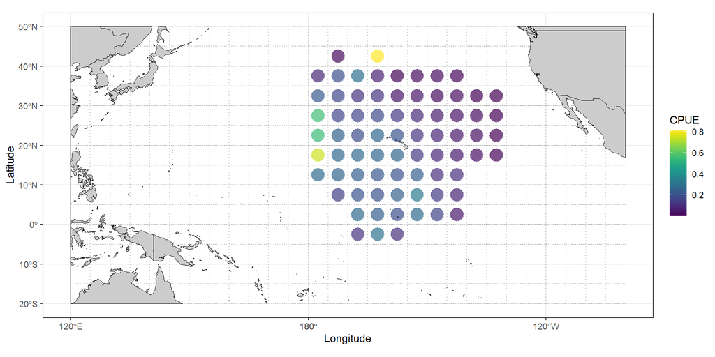

## Model Structure

- Delta-lognormal GLMM for both fleets combined
  - lognormal distribution for positive catches
  - binomial distribution with logit-link function for encounter probability
- Forward step-wise model selection on 13 potential explaintory variables
- Inclusion criteria were based upon an increase of percent deviance explained at least 0.10% and a Chi-squared likelihood ratio test

## Model Structure

- Operational variables:
  - Year
  - Month
  - Quarter
  - Hooks per float
  - bait type
  - Set time (Continuous and factor)
  - Set type
  - Vessel (random effect)
- Spatial and environmental
  - Latitude
  - Longitude
  - SST
  - PDO
  - SOI
  - ONI

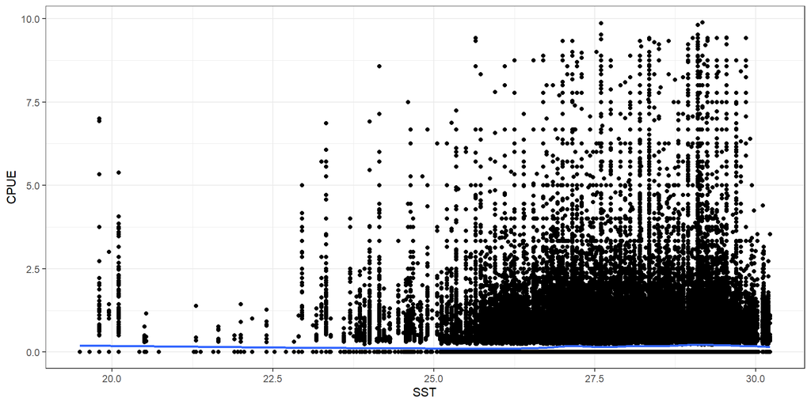

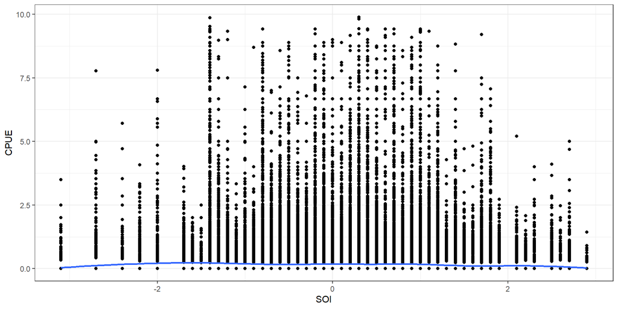

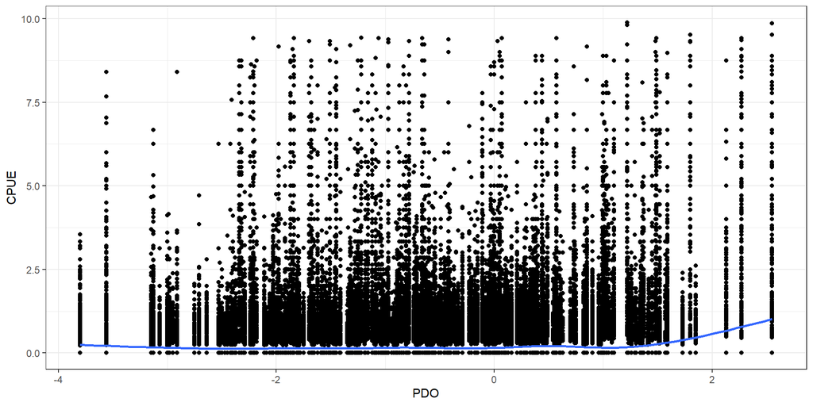

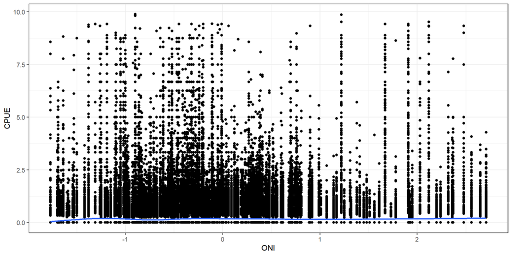

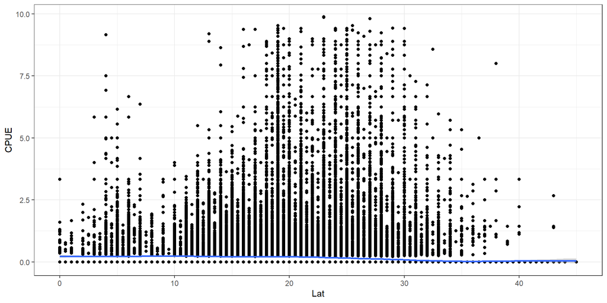

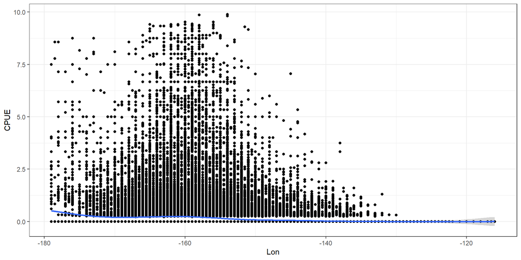

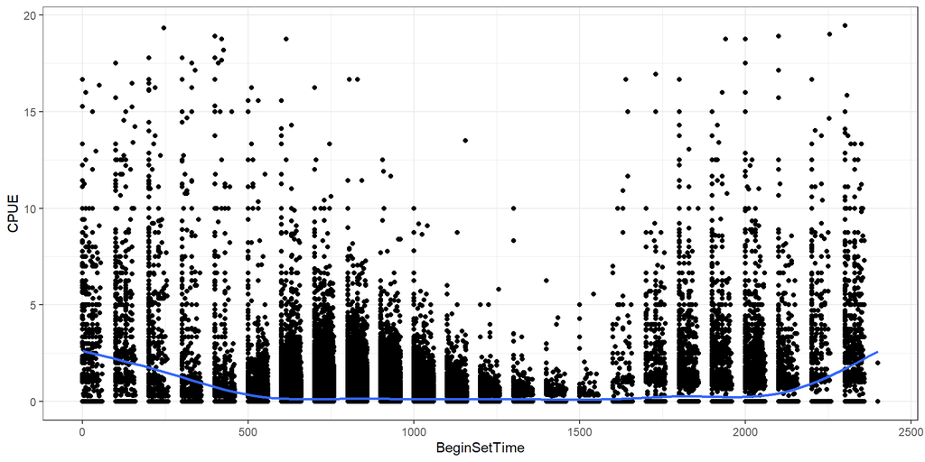

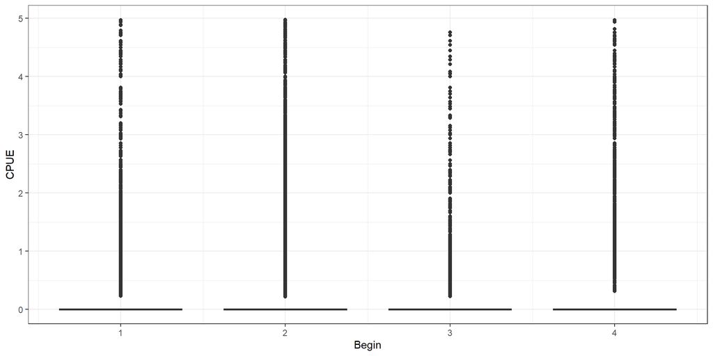

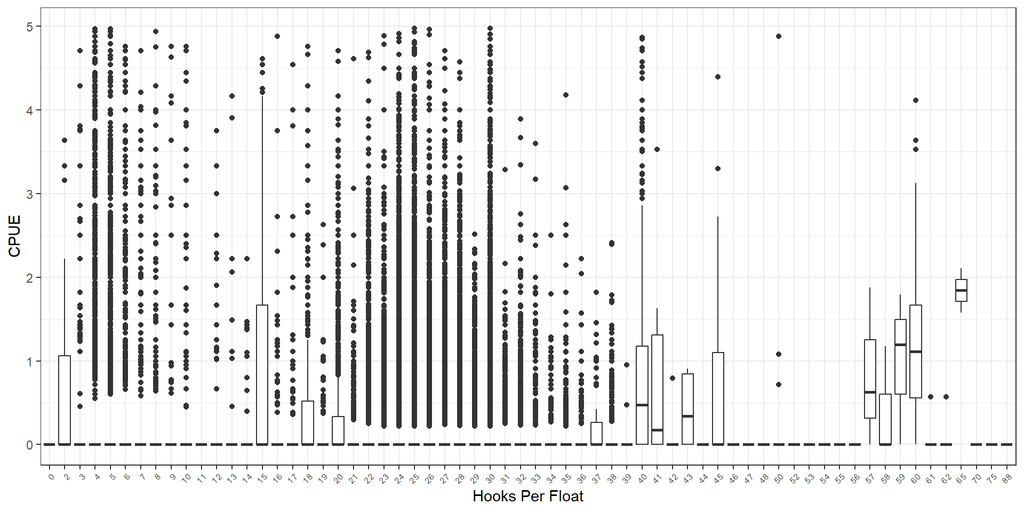

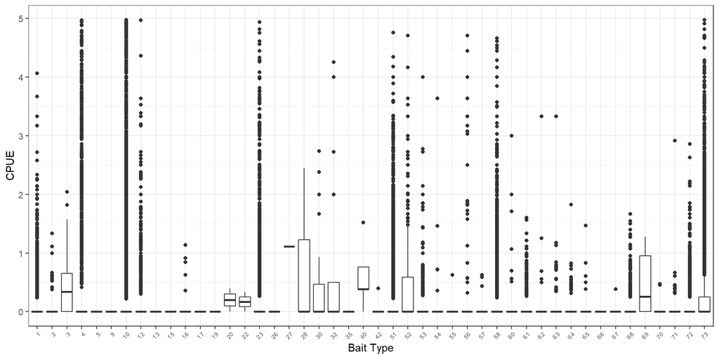

## Final Models

$$Probability of Encounter \sim Latitude + Year + Month + Longitude + Bait + HPF + Begin$$
9.7% Deviance Explained

$$log(CPUE) \sim Bait + Begin + Year + HPF + (1|Vessel)$$
10.2% Deviance Explained

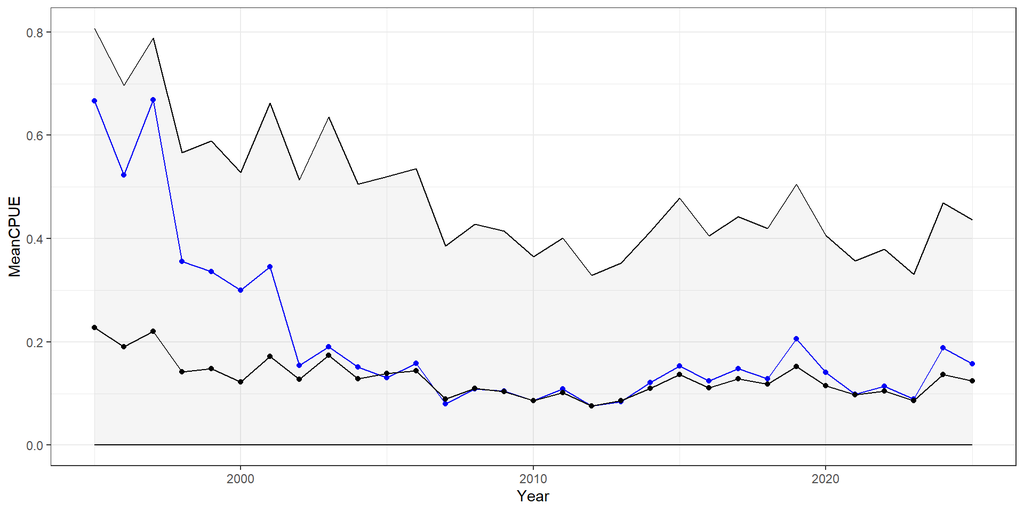

## Diagnostics - Encounter Probability

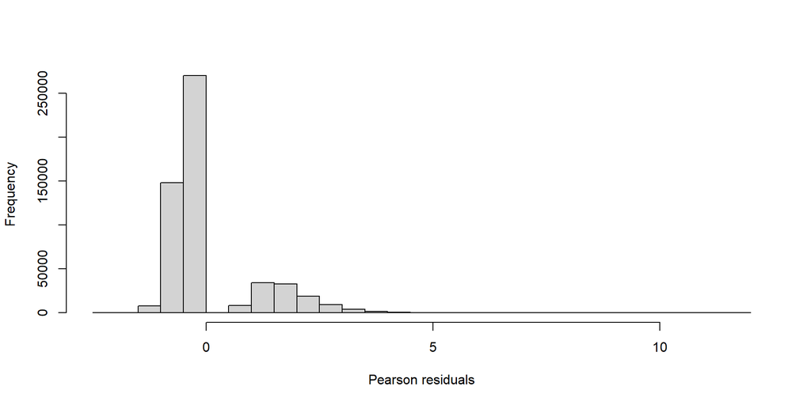

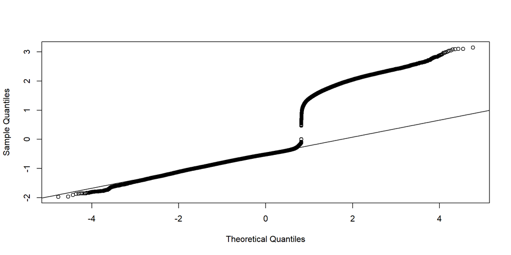

## Diagnostics - Positive Catches

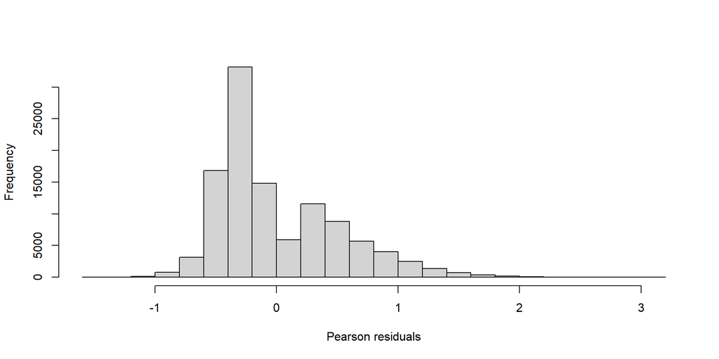

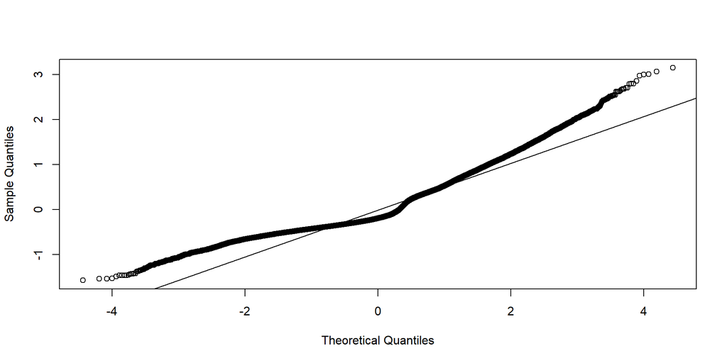

## Partial Dependency Plots

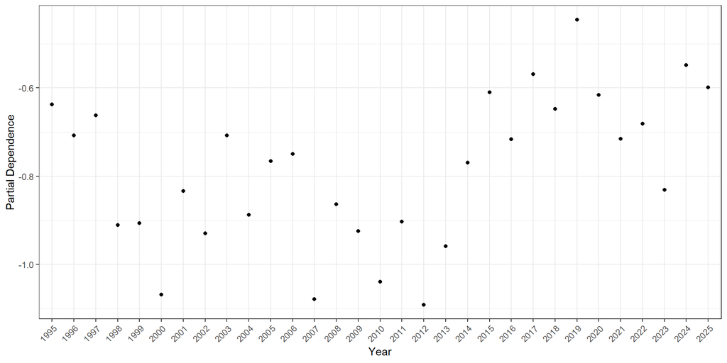

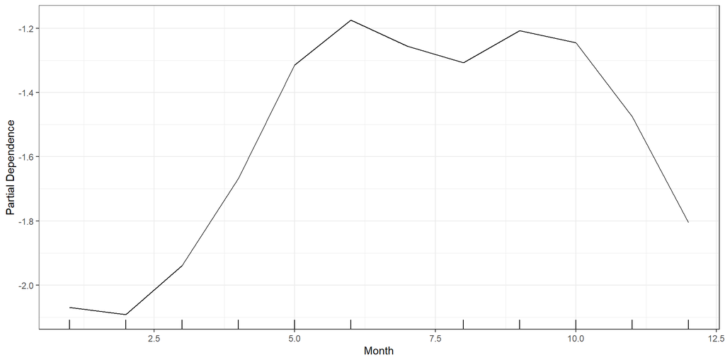

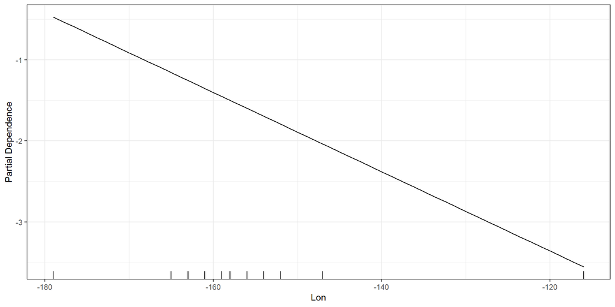

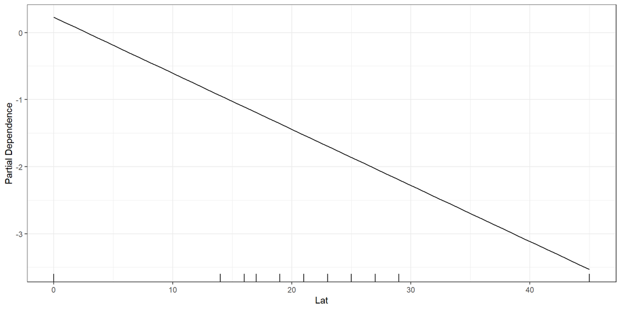

Encounter Probability

## Partial Dependency Plots

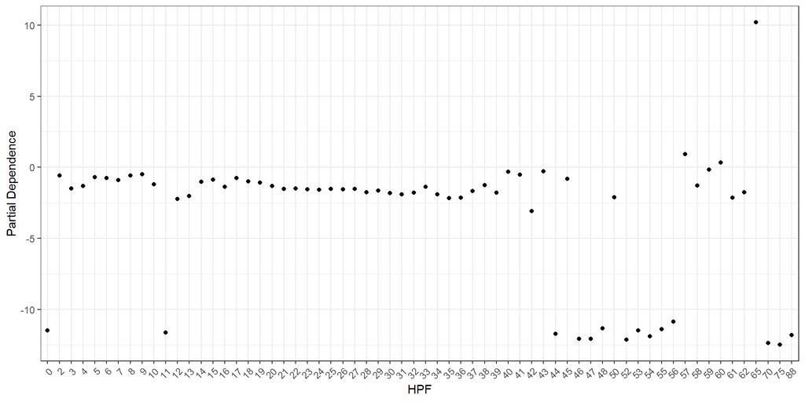

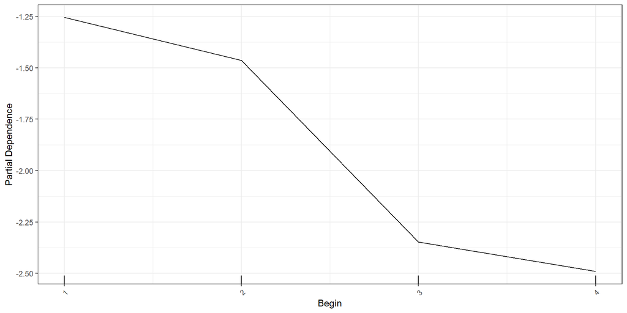

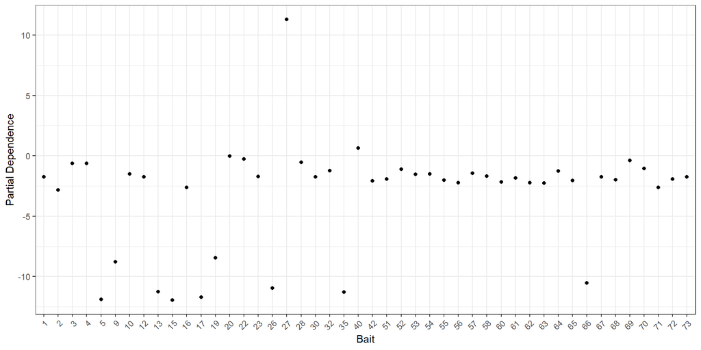

Encounter Probability

## Partial Dependency Plots

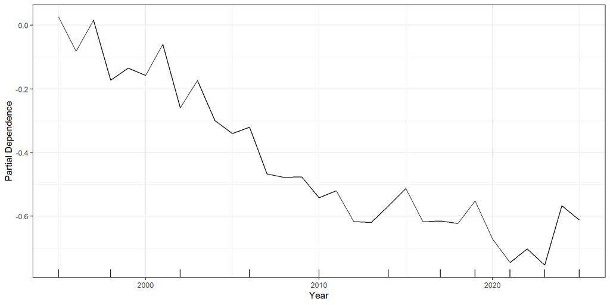

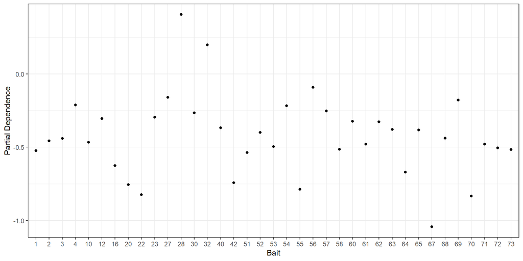

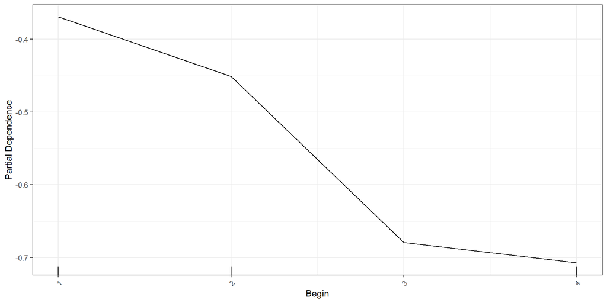

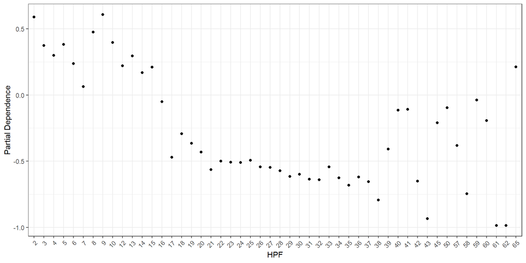

Positivity Catches

## Residual plots - Encounter Probability

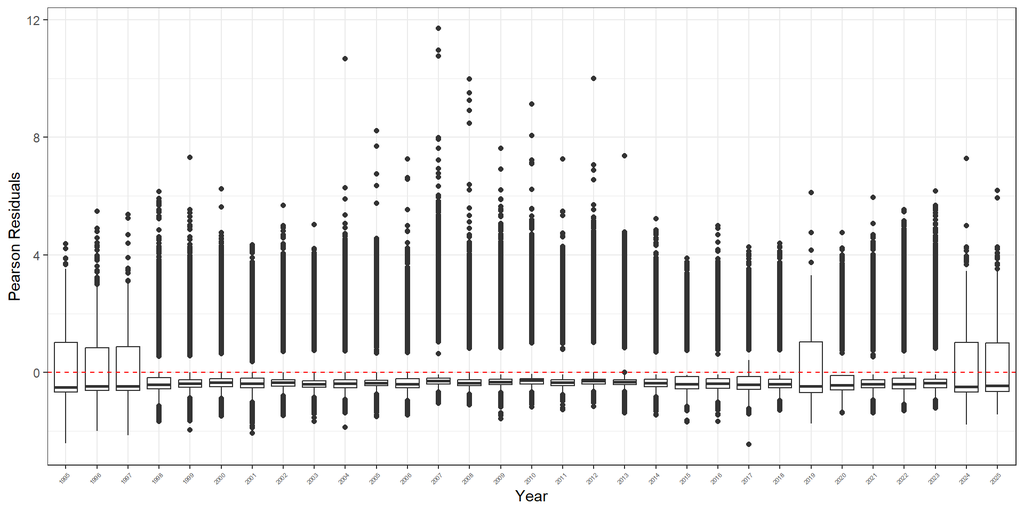

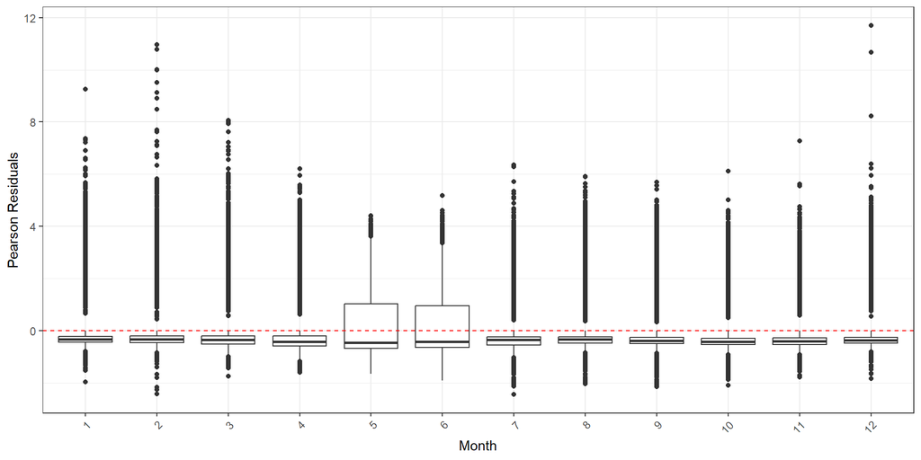

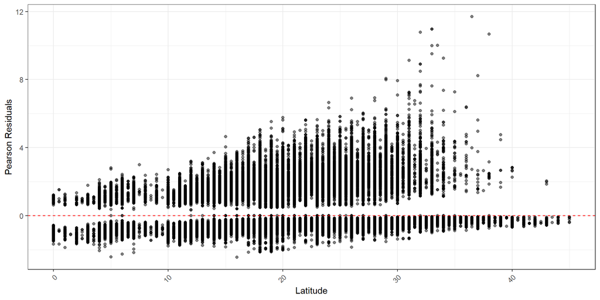

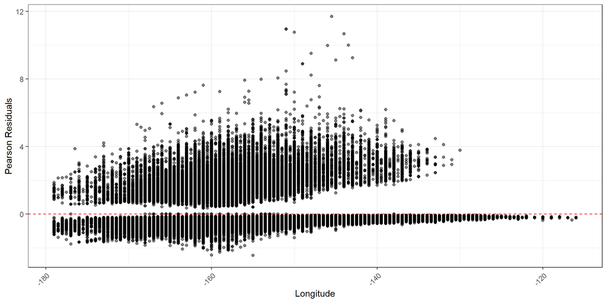